# Bayesian GLM Part1

- error_scatter_avg_vs_x: this is similar to a regular residual plot and as such should be interpreted as such.

```
Using all posterior draws for ppc type 'error_scatter_avg_vs_x' by default.
```

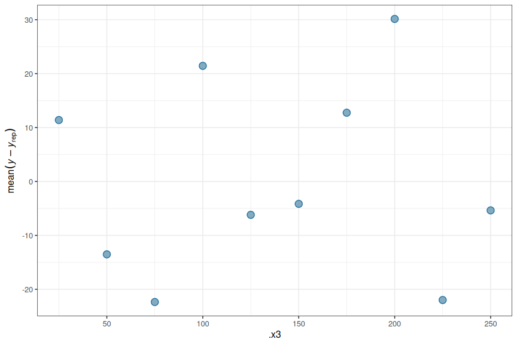

```r
fert_brm3 |> pp_check(x = "FERTILIZER", type = "error_scatter_avg_vs_x")
```

- intervals: plots the observed data overlayed on top of posterior predictions associated with each level of the predictor. Ideally, the observed data should all fall within the predictive intervals.

```
Using all posterior draws for ppc type 'intervals' by default.
```

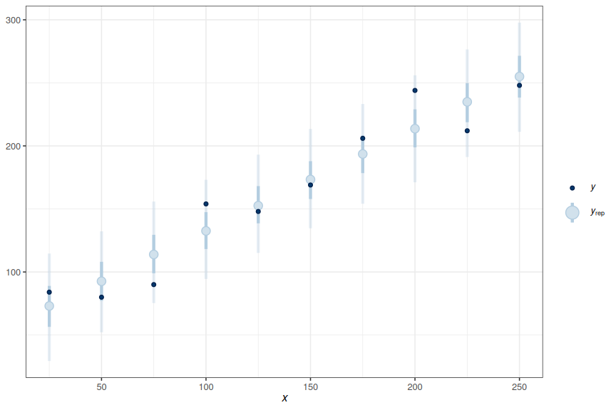

```r
fert_brm3 |> pp_check(x = "FERTILIZER", type = "intervals")
```

- ribbon: this is just an alternative way of expressing the above plot.

```
Using all posterior draws for ppc type 'ribbon' by default.
```

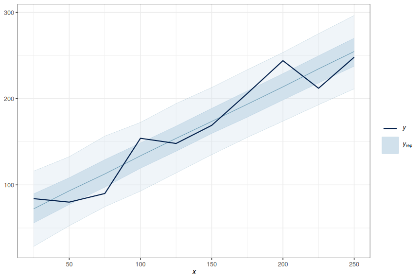

```r
pp_check(fert_brm3, x = "FERTILIZER", type = "ribbon")
```

The `shinystan` package allows the full suite of MCMC diagnostics and posterior predictive checks to be accessed via a web interface.

```r
# library(shinystan)
# launch_shinystan(fert_brm3)
```

**DHARMa residuals**

DHARMa residuals provide very useful diagnostics. Unfortunately, we cannot directly use the `simulateResiduals()` function to generate the simulated residuals. However, if we are willing to calculate some of the components yourself, we can still obtain the simulated residuals from the fitted stan model.

We need to supply:

- simulated (predicted) responses associated with each observation.
- observed values
- fitted (predicted) responses (averaged) associated with each observation

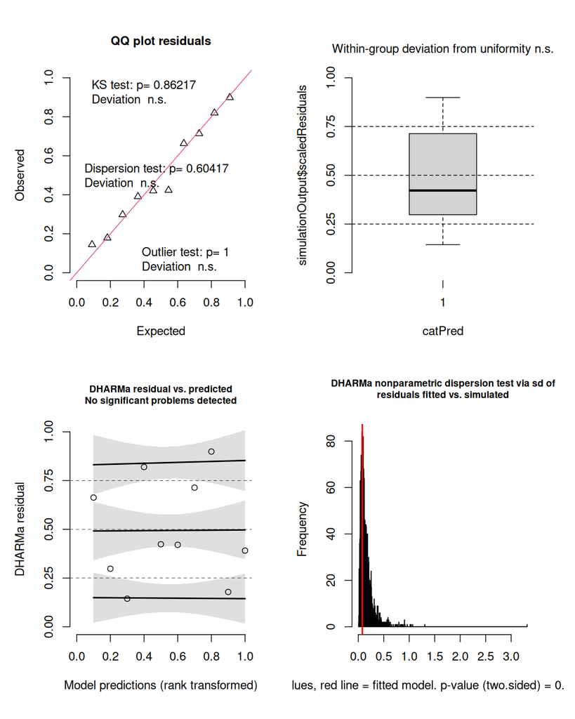

```r
fert.resids <- make_brms_dharma_res(fert_brm3, integerResponse = FALSE)
wrap_elements(~ testUniformity(fert.resids)) +
  wrap_elements(~ plotResiduals(fert.resids, form = factor(rep(1, nrow(fert))))) +
  wrap_elements(~ plotResiduals(fert.resids)) +
  wrap_elements(~ testDispersion(fert.resids))
```

The `integerResponse` argument indicates that noise will be added to the residuals such that they will become integers. This is important in for Poisson, Negative Binomial and Binomial models.

**Conclusions:**

- the simulated residuals do not suggest any issues with the residuals
- there is no evidence of a lack of fit.

The following is the old and (now incorrect) way.

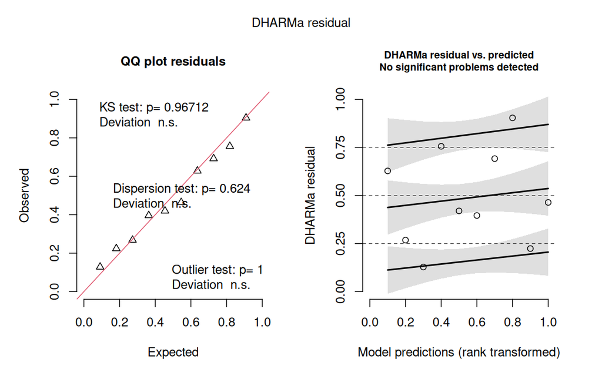

```r
preds <- fert_brm3 |> posterior_predict(ndraws = 250, summary = FALSE)
fert.resids <- createDHARMa(
  simulatedResponse = t(preds),
  observedResponse = fert$YIELD,
  fittedPredictedResponse = apply(preds, 2, median),
  integerResponse = FALSE
)
fert.resids |> plot()
```

**INLA**

**Out-of-sample performance**

`INLA` includes two measures of out-of-sample performace (measures of fit).

- **Conditional Predictive Ordinate (CPO)** is the density of the observed value of $y_i$ within the out-of-sample ($y−i$) posterior predictive distribution. A small CPO value associated with an observation suggests that this observation is unlikely (or surprising) in light of the model, priors and other data in the model. In addition, the sum of the CPO values (or alternatively, the negative of the mean natural logarithm of the CPO values) is a measure of fit.

  ```r
  fert.inla1$cpo$cpo
  ```

  ```
   [1] 0.012299827 0.013183921 0.006748973 0.008780066 0.018831751 0.019056236
   [7] 0.015164579 0.002741200 0.005978481 0.015229534
  ```

  ```r
  sum(fert.inla1$cpo$cop)
  ```

  ```
  [1] 0
  ```

  ```r
  -mean(log(fert.inla1$cpo$cpo))
  ```

  ```
  [1] 4.57854
  ```

  In this case there are no CPO values that are considerably smaller (order of magnitude smaller) than the others - so with respect to the model, none of the observed values would be considered ‘surprising’. Various assumptions are made behind INLA’s computations. If any of these assumptions fail for an observation, it is flagged within (in this case) `cpo$failure` as a non-zero. When this is the case, it is prudent to recalculate the CPO values after removing the observations associated with failure flags not equal to zero and re-fitting the model. This can be performed using the `inla.cpo()` function.

  ```r
  fert.inla1$cpo$failure
  ```

  ```
   [1] 0 0 0 0 0 0 0 0 0 0
  ```

  In this case, there are no non-zero CPO values.
- **Probability Integral Transforms (PIT)** provides a version of CPO that is calibrated to the level of the Gaussian field so that it is clearer whether or not any of the values are ‘small’ (all values must be between 0 and 1). A histogram of PIT values that does not look approximately uniform (flat) indicates a lack of model fit.

  Unfortunately, the following will not work inside of an Rmarkdown (but will work fine on the console)

In this case the PIT values do not appear to deviate from a uniform distribution and thus do not indicate a lack of fit.

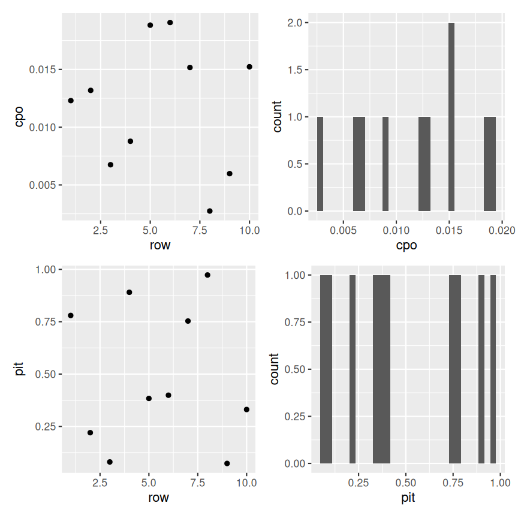

```r
fert.inla1.cpo <- data.frame(
  cpo = fert.inla1$cpo$cpo,
  pit = fert.inla1$cpo$pit,
  failure = fert.inla1$cpo$failure
) |>
  filter(failure == 0) |>
  mutate(row = 1:n())

g1 <- fert.inla1.cpo |>
  ggplot(aes(y = cpo, x = row)) +
  geom_point()
g2 <- fert.inla1.cpo |>
  ggplot(aes(x = cpo)) +
  geom_histogram()
g3 <- fert.inla1.cpo |>
  ggplot(aes(y = pit, x = row)) +
  geom_point()
g4 <- fert.inla1.cpo |>
  ggplot(aes(x = pit)) +
  geom_histogram()

(g1 + g2) / (g3 + g4)
```

Ideally, we want to see that no CPO or PIT is very different in value from any others (not the case here) and that the histograms are relatively flat (which they kind of are here - particularly considering the small amount of data).

In the following, the top left is the distribution of residuals and top right is the observed vs predicted values.

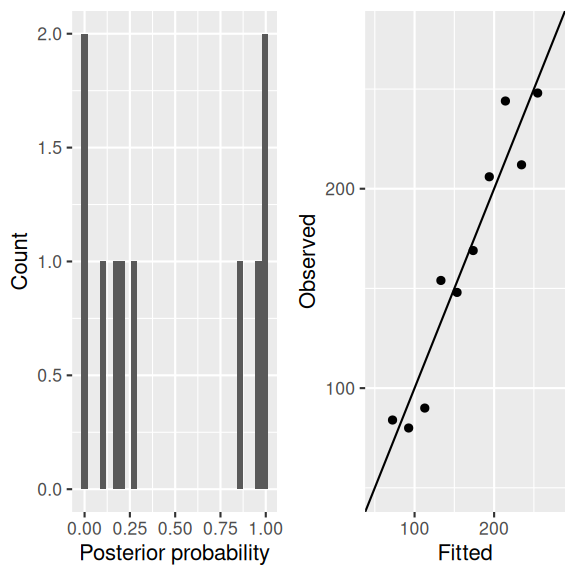

```r
ggplot_inla_residuals(fert.inla1, observed = fert$YIELD)
```

**Conclusions-**

- the distribution of residuals is nearly uniform (keep in mind that the sample size is very small in this example).
- the fitted values approximate the observed values very well

The following figure represents the equivalent of a (standardised) residual plot.

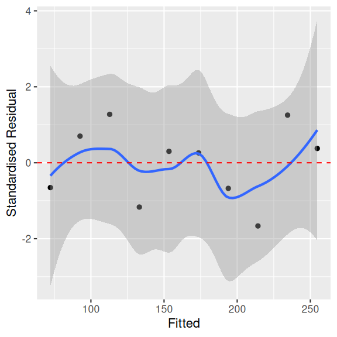

```r
ggplot_inla_residuals2(fert.inla1, observed = fert$YIELD)
```

**DHARMa residuals**

Unfortunately, `DHARMa` does not directly support `INLA`. Therefore, in order to make use of this framework, we need to do some of the heavy lifting. Specifically, we need to generate the posterior predictions associated with the observed data.

Whilst we can draw random samples from the posterior with the `inla.posterior.sample()` *function*, this will only account for uncertainty in the fixed parameter estimates. That is, it will not incorporate the overall uncertainty in the Gaussian distribution ($\sigma$). Therefore, we need to add this back on ourself (keep in mind that this will be in units of precision and thus needs to be back-scaled into units of standard deviation). Furthermore, we will need to use the estimates of standard deviation to estimate the random noise to add onto the predictions. This is done by resampling the family (Gaussian in this case).

I acknowledge that this (resampling the SD) appears to be a bit of a hack and seems to go against the `INLA` principles. Nevertheless, we are only doing this this for the purposes of checking residual diagnostics.

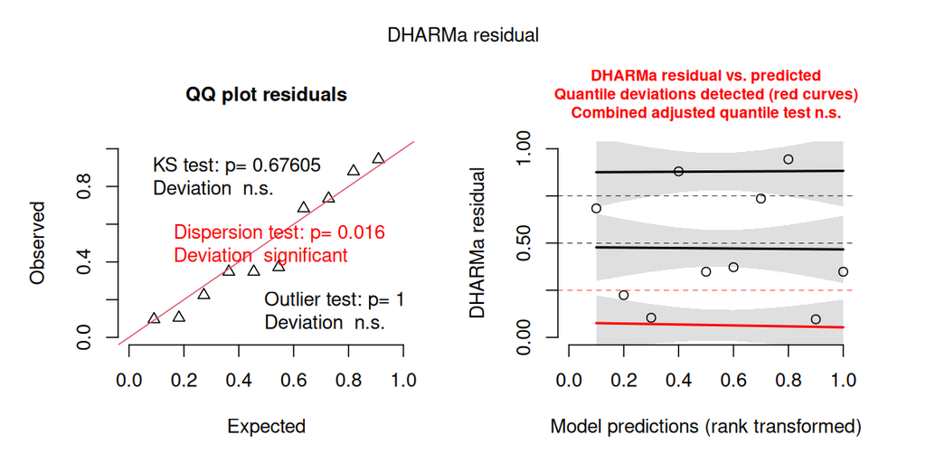

```r
## draw 250 samples from the posterior
draws <- inla.posterior.sample(n = 250, result = fert.inla)
## extract the latent predictions for the observed data
preds <- t(sapply(draws, function(x) x$latent[1:nrow(fert)]))
## extract the first (family precision) hyperprior
preds.hyper <- sapply(draws, function(x) 1 / sqrt(x$hyperpar[[1]]))
## use this to generate gaussian noise
preds.hyper <- rnorm(length(preds.hyper), mean = 0, sd = preds.hyper)
## add the noise to each prediction
preds <- sweep(preds, 1, preds.hyper, FUN = "+")
## generate the DHARMa residuals
fert.resids <- createDHARMa(
  simulatedResponse = t(preds),
  observedResponse = fert$YIELD,
  fittedPredictedResponse = apply(preds, 2, median),
  integerResponse = FALSE
)
fert.resids |> plot()
```

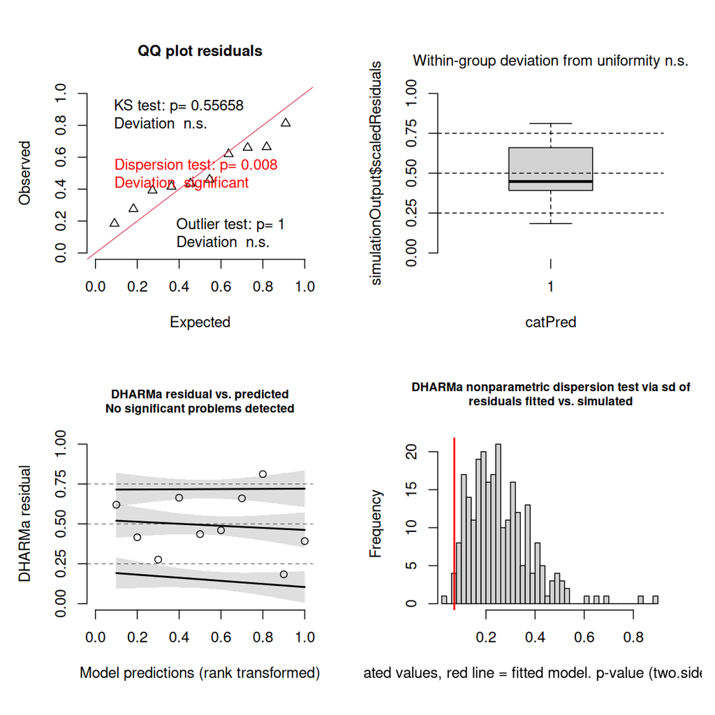

```r
preds <- posterior_predict.inla(fert.inla, newdata = fert)
fert.resids <- createDHARMa(
  simulatedResponse = t(preds),
  observedResponse = fert$YIELD,
  fittedPredictedResponse = apply(preds, 2, mean),
  integerResponse = FALSE
)
wrap_elements(~ testUniformity(fert.resids)) +
  wrap_elements(~ plotResiduals(fert.resids, form = factor(rep(1, nrow(fert))))) +
  wrap_elements(~ plotResiduals(fert.resids)) +
  wrap_elements(~ testDispersion(fert.resids))
```

**Conclusions:**

# 8 Partial effects plots

**rstanarm**

**ggpredict**

```
Data points may overlap. Use the `jitter` argument to add some amount of
  random variation to the location of data points and avoid overplotting.
```

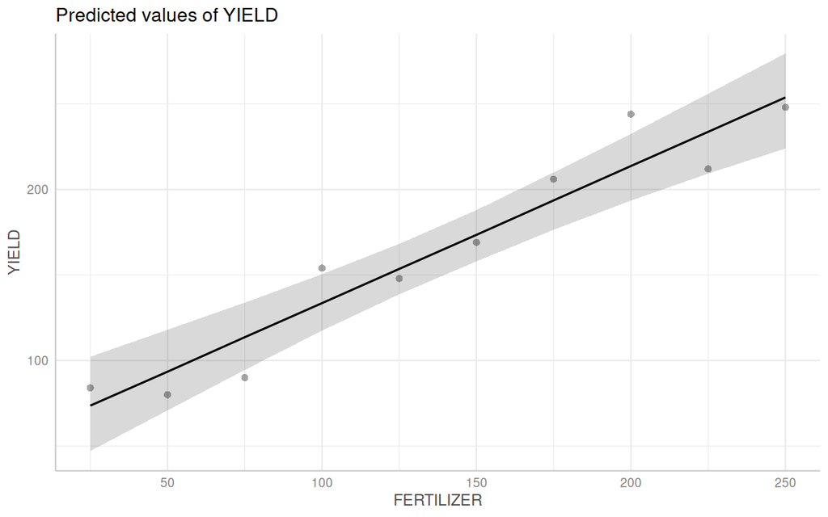

```r
fert.rstanarm3 |>
  ggpredict() |>
  plot(show_data = TRUE)
```

**ggemmeans**

```
Data points may overlap. Use the `jitter` argument to add some amount of
  random variation to the location of data points and avoid overplotting.
```

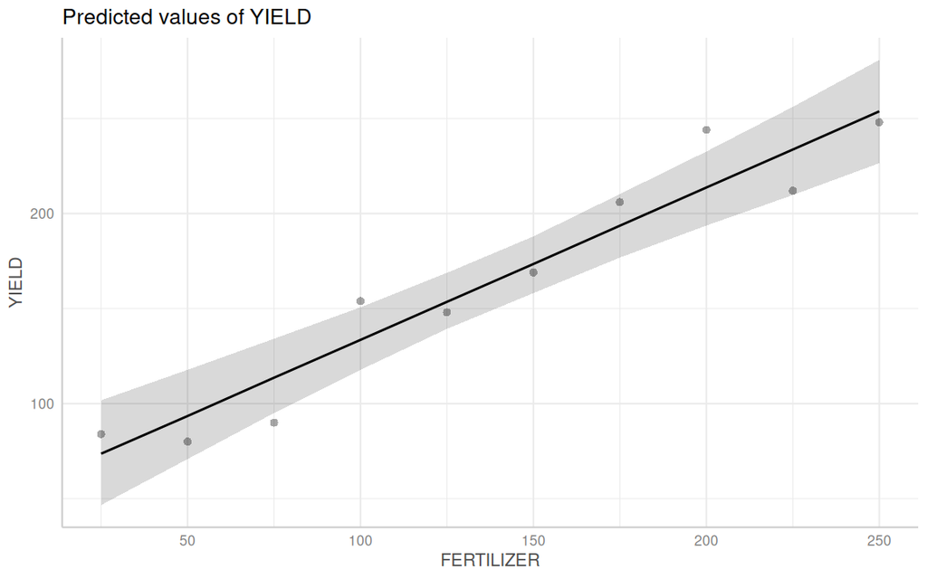

```r
fert.rstanarm3 |>
  ggemmeans(~FERTILIZER) |>
  plot(show_data = TRUE)
```

**epred_draws**

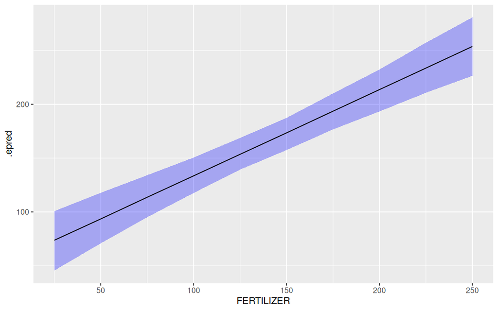

```r
fert.rstanarm3 |>
  epred_draws(newdata = fert) |>
  median_hdci() |>
  ggplot(aes(x = FERTILIZER, y = .epred)) +
  geom_ribbon(aes(ymin = .lower, ymax = .upper), fill = "blue", alpha = 0.3) +
  geom_line()
```

**brms**

**conditional_effects**

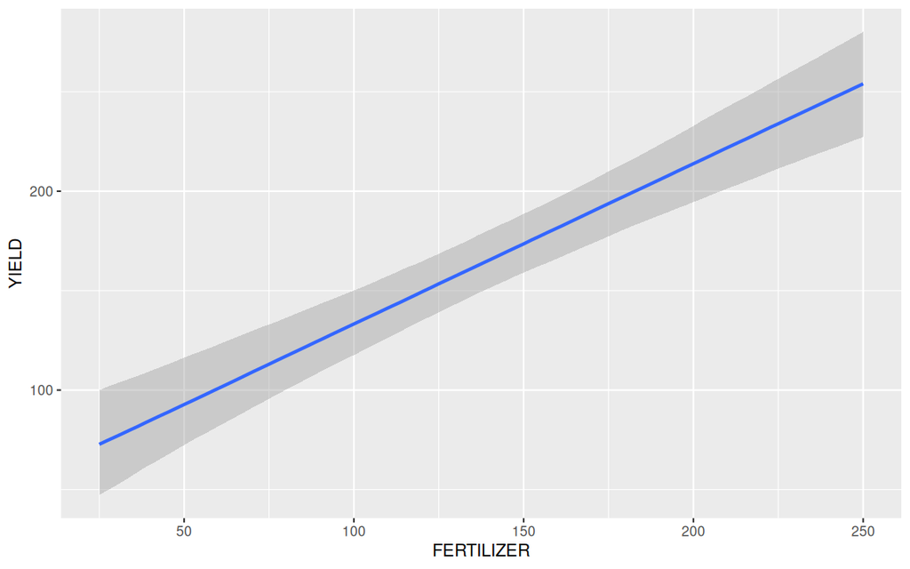

```r
fert_brm3 |> conditional_effects()
```

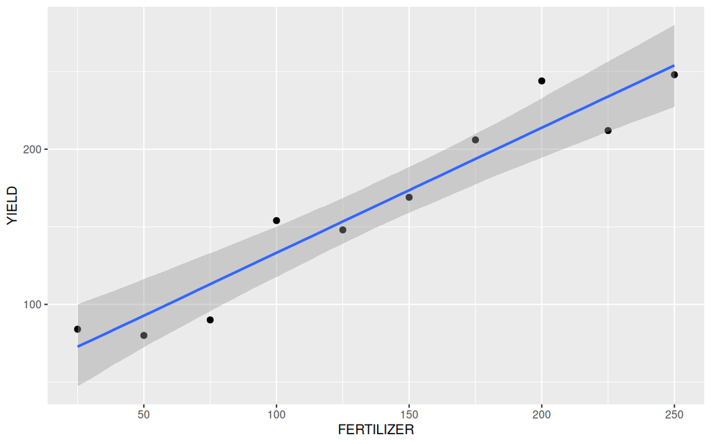

```r
fert_brm3 |>
  conditional_effects() |>
  plot(points = TRUE)
```

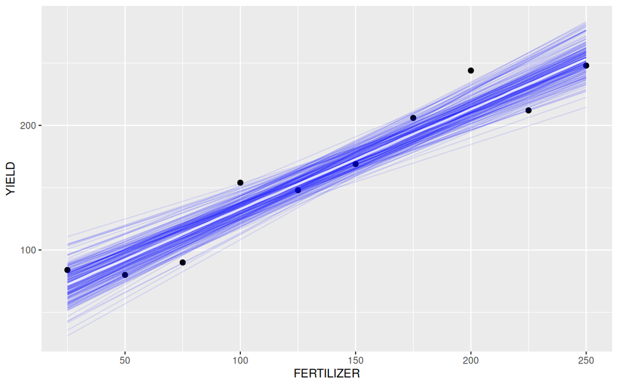

```r
fert_brm3 |>
  conditional_effects(spaghetti = TRUE, ndraws = 200) |>
  plot(points = TRUE)
```

**ggpredict**

```
Data points may overlap. Use the `jitter` argument to add some amount of
  random variation to the location of data points and avoid overplotting.
```

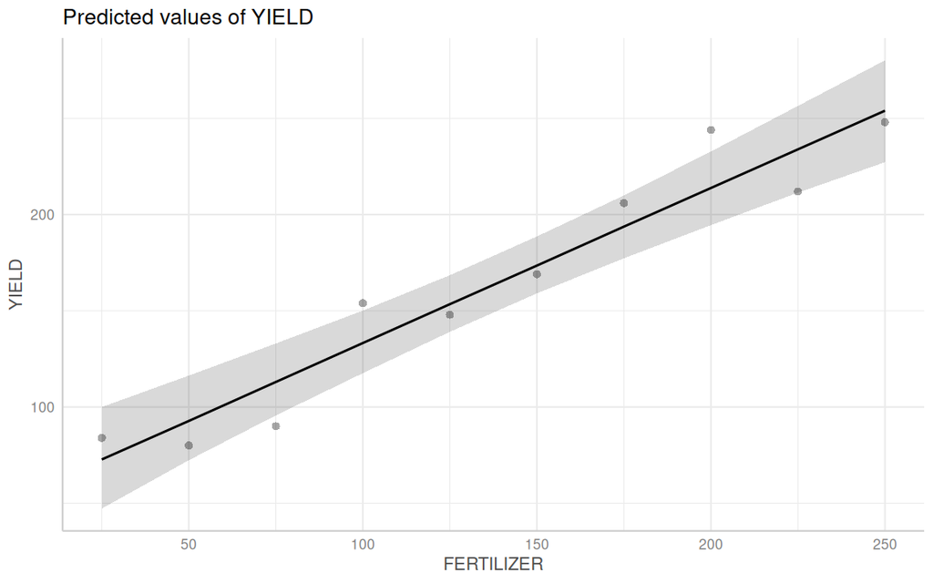

```r
fert_brm3 |>
  ggpredict() |>
  plot(show_data = TRUE)
```

**ggemmeans**

```
Data points may overlap. Use the `jitter` argument to add some amount of
  random variation to the location of data points and avoid overplotting.
```

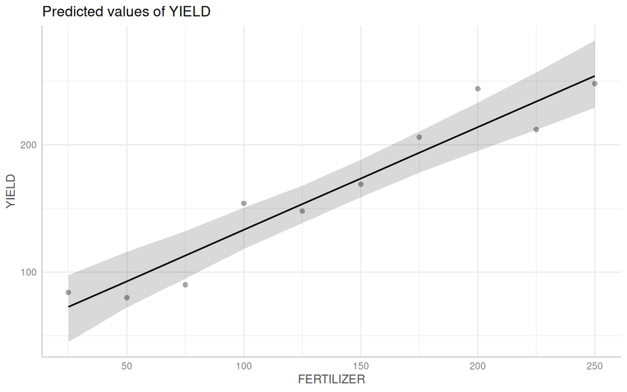

```r
fert_brm3 |>
  ggemmeans(~FERTILIZER) |>
  plot(show_data = TRUE)
```

**epred_draws**

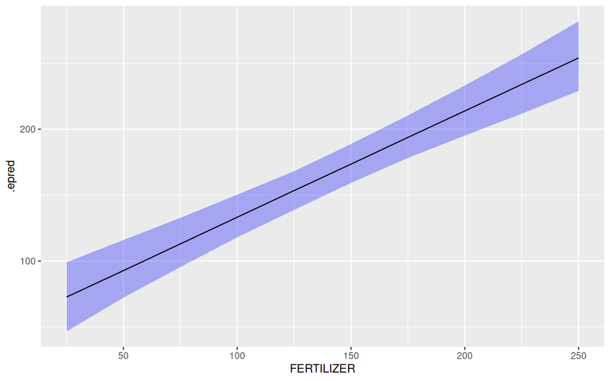

```r
fert_brm3 |>
  epred_draws(newdata = fert) |>
  median_hdci() |>
  ggplot(aes(x = FERTILIZER, y = .epred)) +
  geom_ribbon(aes(ymin = .lower, ymax = .upper), fill = "blue", alpha = 0.3) +
  geom_line()
```

**INLA**

```r
plot(fert.inla1,
  plot.fixed.effects = FALSE,
  plot.lincomb = FALSE,
  plot.random.effects = FALSE,
  plot.hyperparameters = FALSE,
  plot.predictor = TRUE,
  plot.q = FALSE,
  plot.cpo = FALSE,
  plot.prior = FALSE
)
```

[output not shown]

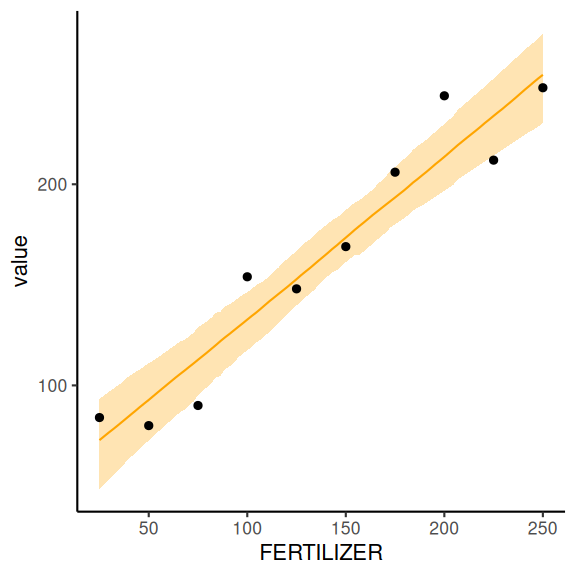

```r
newdata <- fert |> tidyr::expand(FERTILIZER = modelr::seq_range(FERTILIZER, n = 100))
Xmat <- model.matrix(~FERTILIZER, newdata)

nms <- colnames(fert.inla1$model.matrix)
n <- sapply(nms, function(x) 0, simplify = FALSE)
draws <- inla.posterior.sample(n = 250, result = fert.inla1, selection = n)
coefs <- t(sapply(draws, function(x) x$latent))
Fit <- coefs %*% t(Xmat) |>
  as.data.frame() |>
  mutate(Rep = 1:n()) |>
  pivot_longer(cols = -Rep) |>
  group_by(name) |>
  median_hdci(value) |>
  ungroup() |>
  mutate(name = as.integer(as.character(name))) |>
  arrange(name)
newdata <- newdata |>
  bind_cols(Fit)

newdata |>
  ggplot(aes(x = FERTILIZER)) +
  geom_ribbon(aes(ymin = .lower, ymax = .upper), fill = "orange", color = NA, alpha = 0.3) +
  geom_line(aes(y = value), color = "orange") +
  geom_point(data = fert, aes(y = YIELD)) +
  theme_classic()
```

# 9 Model investigation

Rather than simply return point estimates of each of the model parameters, Bayesian analyses capture the full posterior of each parameter. These are typically stored within the `list` structure of the output object.

As with most statistical routines, the overloaded `summary()` function provides an overall summary of the model parameters. Typically, the summaries will include the means / medians along with credibility intervals and perhaps convergence diagnostics (such as R hat). However, more thorough investigation and analysis of the parameter posteriors requires access to the full posteriors.

There is currently a plethora of functions for extracting the full posteriors from models. In part, this is a reflection of a rapidly evolving space with numerous packages providing near equivalent functionality (it should also be noted, that over time, many of the functions have been deprecated due to inconsistencies in their names). Broadly speaking, the functions focus on draws from the posterior of either the parameters (intercept, slope, standard deviation etc), **linear predictor**, **expected values** or **predicted values**. The distinction between the latter three are highlighted in the following table.

| Property | Description |
| --- | --- |
| linear predictors | values predicted on the link scale |
| expected values | predictions (on response scale) without residual error (predicting expected mean outcome(s)) |
| predicted values | predictions (on response scale) that incorporate residual error |
| fitted values | predictions on the response scale |

The following table lists the various ways of extracting the full posteriors of the model parameters parameters, **expected** values and **predicted** values. The crossed out items are now deprecated and function with a namespace of `__` mean that the functionality is provided via a range of packages.

| Function | Values | Description |
| --- | --- | --- |
| `__::as.matrix()` | Parameters | Returns $n\times p$ matrix |
| `__::as.data.frame()` | Parameters | Returns $n\times p$ data.frame |
| `__::as_tibble()` | Parameters | Returns $n\times p$ tibble |
| `posterior::as_draws_df()` | Parameters | Returns $n\times p$ data.frame with additional info about chain, interaction and draw |
| `brms::posterior_samples()` | Parameters | Returns $n\times p$ data.frame |
| `tidybayes::tidy_draws()` | Parameters | Returns $n\times p$ tibble with addition info about the chain, iteration and draw |
| `rstan::extract()` | Parameters | Returns a $p$ length list of $n$ length vectors |
| `tidybayes::spread_draws()` | Parameters | Returns $n\times r$ tibble with additional info about chain, interaction and draw |
| `tidybayes::gather_draws()` | Parameters | Returns a gathered `spread_draws` tibble with additional info about chain, interaction and draw |
| `rstanarm::posterior_linpred()` | Linear predictors | Returns $n\times N$ tibble on the link scale |
| `brms::posterior_linpred()` | Linear predictors | Returns $n\times N$ tibble on the link scale |
| `tidybayes::linpred_draws()` | Linear predictors | Returns tibble with $nN rows and `.linpred` on the link scale additional info about chain, interaction and draw |
| `rstanarm::posterior_epred()` | Expected values | Returns $n\times N$ tibble on the response scale |
| `brms::posterior_epred()` | Expected values | Returns $n\times N$ tibble on the response scale |
| `tidybayes::epred_draws()` | Expected values | Returns tibble with $nN rows and `.epred` on the response scale additional info about chain, interaction and draw |
| `rstanarm::posterior_predict()` | Expected values | Returns $n\times N$ tibble of predictions (including residuals) on the response scale |
| `brms::posterior_predict()` | Expected values | Returns $n\times N$ tibble of predictions (including residuals) on the response scale |
| `tidybayes::predicted_draws()` | Expected values | Returns tibble with $nN rows and `.prediction` (including residuals) on the response scale additional info about chain, interaction and draw |

where $n$ is the number of MCMC samples and $p$ is the number of parameters to estimate, $N$ is the number of newdata rows and $r$ is the number of requested parameters. For the `tidybayes` versions in the table above, the function expects a model to be the first parameter (and a dataframe to be the second). There are also `add_` versions which expect a dataframe to be the first argument and the model to be the second. These alternatives facilitate pipings with different starting objects.

| Function | Description |
| --- | --- |
| `median_qi` | Median and quantiles of specific columns |
| `median_hdi` | Median and Highest Probability Density Interval of specific columns |
| `median_hdci` | Median and continuous Highest Probability Density Interval of specific columns |
| `tidyMCMC` | Median/mean and quantiles/hpd of all columns |

It is important to remember that when working with Bayesian models, everything is a distribution. Whilst point estimates (such as a mean) of the parameters can be calculated from these distributions, we start off with a large number of estimates per parameter.

**rstanarm**

`rstanarm` captures the MCMC samples from `stan` within the returned list. There are numerous ways to retrieve and summarise these samples. The first three provide convenient numeric summaries from which you can draw conclusions, the last four provide ways of obtaining the full posteriors.

**summary**

The `summary()` method generates simple summaries (mean, standard deviation as well as 10, 50 and 90 percentiles).

```r
fert.rstanarm3 |> summary()
```

```
Model Info:
 function:     stan_glm
 family:       gaussian [identity]
 formula:      YIELD ~ scale(FERTILIZER)
 algorithm:    sampling
 sample:       2400 (posterior sample size)
 priors:       see help('prior_summary')
 observations: 10
 predictors:   2

Estimates:
                    mean   sd    10%   50%   90%
(Intercept)       163.6    7.4 154.8 163.5 172.7
scale(FERTILIZER)  60.3    7.8  50.8  60.6  69.8
sigma              22.5    7.2  15.3  21.0  31.2

Fit Diagnostics:
           mean   sd    10%   50%   90%
mean_PPD 163.4   10.7 150.5 163.6 176.2

The mean_ppd is the sample average posterior predictive distribution of the outcome variable (for details see help('summary.stanreg')).

MCMC diagnostics
                  mcse Rhat n_eff
(Intercept)       0.1  1.0  2646
scale(FERTILIZER) 0.2  1.0  2337
sigma             0.2  1.0  2122
mean_PPD          0.2  1.0  2574
log-posterior     0.0  1.0  1777

For each parameter, mcse is Monte Carlo standard error, n_eff is a crude measure of effective sample size, and Rhat is the potential scale reduction factor on split chains (at convergence Rhat=1).
```

**Conclusions:**

**tidyMCMC**

```r
tidyMCMC(fert.rstanarm3$stanfit,
  estimate.method = "median", conf.int = TRUE,
  conf.method = "HPDinterval", rhat = TRUE, ess = TRUE
)
```

```
# A tibble: 5 × 7
  term              estimate std.error conf.low conf.high  rhat   ess
  <chr>                <dbl>     <dbl>    <dbl>     <dbl> <dbl> <int>
1 (Intercept)          164.       7.40    150.      179.  1.000  2646
2 scale(FERTILIZER)     60.3      7.81     46.0      76.7 0.999  2337
3 sigma                 22.5      7.25     12.3      36.9 1.00   2122
4 mean_PPD             163.      10.7     143.      186.  0.999  2574
5 log-posterior        -52.4      1.47    -55.3     -50.7 1.00   1777
```

**Conclusions:**

**summarise_draws (posterior)**

```r
fert.rstanarm3$stanfit |>
  summarise_draws(
    median,
    HDInterval::hdi,
    rhat, length, ess_bulk, ess_tail
  )
```

```
# A tibble: 5 × 8
  variable          median lower upper  rhat length ess_bulk ess_tail
  <chr>              <dbl> <dbl> <dbl> <dbl>  <dbl>    <dbl>    <dbl>
1 (Intercept)        163.  150.  179.  1.00    2400    2656.    2288.
2 scale(FERTILIZER)   60.6  46.0  76.7 1.000   2400    2338.    2364.
3 sigma               21.0  12.3  36.9 1.00    2400    2158.    2321.
4 mean_PPD           164.  143.  186.  1.000   2400    2548.    2332.
5 log-posterior      -52.1 -55.3 -50.7 1.00    2400    1910.    1858.
```

We can also alter the CI level.

```r
fert.rstanarm3$stanfit |>
  summarise_draws(
    median,
    ~ HDInterval::hdi(.x, credMass = 0.9),
    rhat, length, ess_bulk, ess_tail
  )
```

```
# A tibble: 5 × 8
  variable          median lower upper  rhat length ess_bulk ess_tail
  <chr>              <dbl> <dbl> <dbl> <dbl>  <dbl>    <dbl>    <dbl>
1 (Intercept)        163.  153.  176.  1.00    2400    2656.    2288.
2 scale(FERTILIZER)   60.6  48.5  72.9 1.000   2400    2338.    2364.
3 sigma               21.0  12.4  31.7 1.00    2400    2158.    2321.
4 mean_PPD           164.  147.  180.  1.000   2400    2548.    2332.
5 log-posterior      -52.1 -54.4 -50.7 1.00    2400    1910.    1858.
```

**as_draws_df (posterior)**

```r
fert.rstanarm3$stanfit |> as_draws_df()
```

```
# A draws_df: 800 iterations, 3 chains, and 5 variables
   (Intercept) scale(FERTILIZER) sigma mean_PPD log-posterior
1          195                57    35      207           -58
2          160                86    26      156           -56
3          162                65    19      157           -51
4          166                56    24      168           -51
5          167                68    17      164           -52
6          153                59    16      149           -53
7          151                56    25      145           -53
8          165                70    23      164           -52
9          156                42    24      163           -55
10         175                60    30      168           -53
# ... with 2390 more draws
# ... hidden reserved variables {'.chain', '.iteration', '.draw'}
```

```r
fert.rstanarm3$stanfit |>
  as_draws_df() |>
  summarise_draws(
    median,
    ~ HDInterval::hdi(.x),
    rhat,
    ess_bulk, ess_tail
  )
```

```
# A tibble: 5 × 7
  variable          median lower upper  rhat ess_bulk ess_tail
  <chr>              <dbl> <dbl> <dbl> <dbl>    <dbl>    <dbl>
1 (Intercept)        163.  150.  179.  1.00     2656.    2288.
2 scale(FERTILIZER)   60.6  46.0  76.7 1.000    2338.    2364.
3 sigma               21.0  12.3  36.9 1.00     2158.    2321.
4 mean_PPD           164.  143.  186.  1.000    2548.    2332.
5 log-posterior      -52.1 -55.3 -50.7 1.00     1910.    1858.
```

**tidy_draws**

```r
fert.rstanarm3 |> tidy_draws()
```

```
# A tibble: 2,400 × 12
   .chain .iteration .draw `(Intercept)` `scale(FERTILIZER)` sigma accept_stat__
    <int>      <int> <int>         <dbl>               <dbl> <dbl>         <dbl>
 1      1          1     1          195.                56.7  34.8         0.976
 2      1          2     2          160.                85.7  26.2         0.867
 3      1          3     3          162.                65.1  18.9         0.984
 4      1          4     4          166.                56.4  23.5         0.924
 5      1          5     5          167.                67.7  16.7         0.999
 6      1          6     6          153.                59.4  16.0         0.987
 7      1          7     7          151.                55.8  25.1         0.987
 8      1          8     8          165.                69.7  23.1         0.996
 9      1          9     9          156.                41.9  24.1         0.962
10      1         10    10          175.                60.4  30.2         0.908
# ℹ 2,390 more rows
# ℹ 5 more variables: stepsize__ <dbl>, treedepth__ <dbl>, n_leapfrog__ <dbl>,
#   divergent__ <dbl>, energy__ <dbl>
```

**gather_draws**

```r
fert.draw <- fert.rstanarm3 |> gather_draws(`(Intercept)`, `scale(FERTILIZER)`, sigma)
## OR via regex
fert.draw <- fert.rstanarm3 |> gather_draws(`.Intercept.*|.*FERT.*|sigma`, regex = TRUE)
fert.draw
```

```
# A tibble: 7,200 × 5
# Groups:   .variable [3]
   .chain .iteration .draw .variable   .value
    <int>      <int> <int> <chr>        <dbl>
 1      1          1     1 (Intercept)   195.
 2      1          2     2 (Intercept)   160.
 3      1          3     3 (Intercept)   162.
 4      1          4     4 (Intercept)   166.
 5      1          5     5 (Intercept)   167.
 6      1          6     6 (Intercept)   153.
 7      1          7     7 (Intercept)   151.
 8      1          8     8 (Intercept)   165.
 9      1          9     9 (Intercept)   156.
10      1         10    10 (Intercept)   175.
# ℹ 7,190 more rows
```

We can then summarise this

```r
fert.draw |> median_hdci()
```

```
# A tibble: 3 × 7
  .variable         .value .lower .upper .width .point .interval
  <chr>              <dbl>  <dbl>  <dbl>  <dbl> <chr>  <chr>
1 (Intercept)        163.   149.   178.    0.95 median hdci
2 scale(FERTILIZER)   60.6   45.3   76.0   0.95 median hdci
3 sigma               21.0   12.5   37.3   0.95 median hdci
```

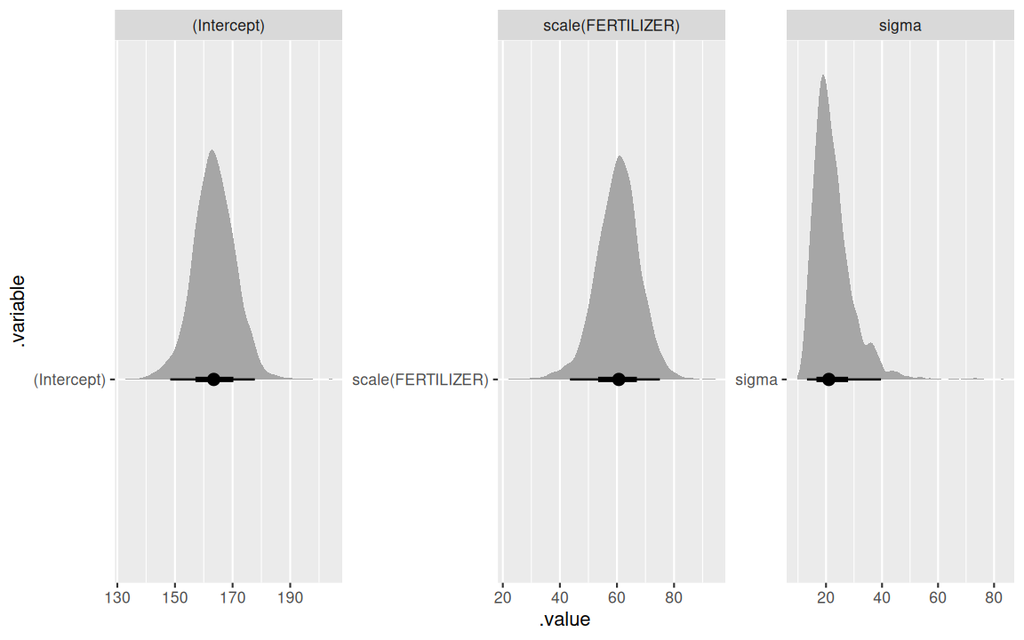

```r
fert.rstanarm3 |>
  gather_draws(`(Intercept)`, `scale(FERTILIZER)`, sigma) |>
  ggplot() +
  stat_halfeye(aes(x = .value, y = .variable)) +
  facet_wrap(~.variable, scales = "free")
```

**Conclusions:**

- the estimated intercept (expected yield when fertilizer concentration is 0) is 163.46. This is the median of the posterior distribution for this parameter.
- the estimated slope (rate at which yield changes per 1 unit change in fertilizer concentration), is 60.65 (mean) or (median). The 95% credibility intervals indicate that we are 95% confident that the slope is between 45.29 and 75.99 - e.g. there is a significant positive trend.
- sigma is estimated to be 21.01

**bayesplot**

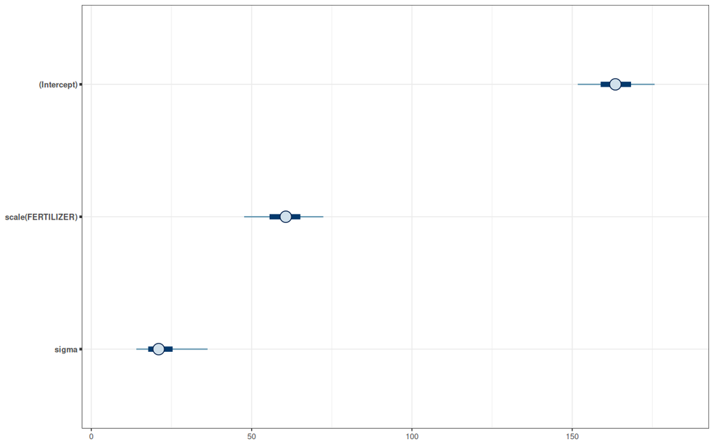

```r
fert.rstanarm3 |> plot(plotfun = "mcmc_intervals")
```

**spread_draws**

```r
fert.rstanarm3 |> spread_draws(`(Intercept)`, `scale(FERTILIZER)`, sigma)
```

```
# A tibble: 2,400 × 6
   .chain .iteration .draw `(Intercept)` `scale(FERTILIZER)` sigma
    <int>      <int> <int>         <dbl>               <dbl> <dbl>
 1      1          1     1          195.                56.7  34.8
 2      1          2     2          160.                85.7  26.2
 3      1          3     3          162.                65.1  18.9
 4      1          4     4          166.                56.4  23.5
 5      1          5     5          167.                67.7  16.7
 6      1          6     6          153.                59.4  16.0
 7      1          7     7          151.                55.8  25.1
 8      1          8     8          165.                69.7  23.1
 9      1          9     9          156.                41.9  24.1
10      1         10    10          175.                60.4  30.2
# ℹ 2,390 more rows
```

```r
# OR via regex
fert.rstanarm3 |> spread_draws(`.Intercept.*|.*FERT.*|sigma`, regex = TRUE)
```

```
# A tibble: 2,400 × 6
   .chain .iteration .draw `(Intercept)` `scale(FERTILIZER)` sigma
    <int>      <int> <int>         <dbl>               <dbl> <dbl>
 1      1          1     1          195.                56.7  34.8
 2      1          2     2          160.                85.7  26.2
 3      1          3     3          162.                65.1  18.9
 4      1          4     4          166.                56.4  23.5
 5      1          5     5          167.                67.7  16.7
 6      1          6     6          153.                59.4  16.0
 7      1          7     7          151.                55.8  25.1
 8      1          8     8          165.                69.7  23.1
 9      1          9     9          156.                41.9  24.1
10      1         10    10          175.                60.4  30.2
# ℹ 2,390 more rows
```

**posterior_samples**

```r
fert.rstanarm3 |>
  posterior_samples() |>
  as_tibble()
```

```
# A tibble: 2,400 × 3
   `(Intercept)` `scale(FERTILIZER)` sigma
           <dbl>               <dbl> <dbl>
 1          195.                56.7  34.8
 2          160.                85.7  26.2
 3          162.                65.1  18.9
 4          166.                56.4  23.5
 5          167.                67.7  16.7
 6          153.                59.4  16.0
 7          151.                55.8  25.1
 8          165.                69.7  23.1
 9          156.                41.9  24.1
10          175.                60.4  30.2
# ℹ 2,390 more rows
```

**\(R^2\)**

```r
fert.rstanarm3 |>
  bayes_R2() |>
  median_hdci()
```

```
          y      ymin      ymax .width .point .interval
1 0.8922825 0.6916412 0.9653292   0.95 median      hdci
```

**Empirical p-value**

It is possible to obtain an empirical p-value (for those that cannot live without p-values). This is essentially compares (for any posterior) that the mean is zero compared to a multivariate distribution with elliptical contours.

```r
mcmcpvalue <- function(samp) {
  ## elementary version that creates an empirical p-value for the
  ## hypothesis that the columns of samp have mean zero versus a
  ## general multivariate distribution with elliptical contours.

  ## differences from the mean standardized by the observed
  ## variance-covariance factor

  ## Note, I put in the bit for single terms
  if (length(dim(samp)) == 0) {
    std <- backsolve(chol(var(samp)), cbind(0, t(samp)) - mean(samp), transpose = TRUE)
    sqdist <- colSums(std * std)
    sum(sqdist[-1] > sqdist[1]) / length(samp)
  } else {
    std <- backsolve(chol(var(samp)), cbind(0, t(samp)) - colMeans(samp), transpose = TRUE)
    sqdist <- colSums(std * std)
    sum(sqdist[-1] > sqdist[1]) / nrow(samp)
  }
}

mcmcpvalue(as.matrix(fert.rstanarm3)[, c("scale(FERTILIZER)")])
```

```
[1] 0
```

**brms**

`brms` captures the MCMC samples from `stan` within the returned list. There are numerous ways to retrieve and summarise these samples. The first three provide convenient numeric summaries from which you can draw conclusions, the last four provide ways of obtaining the full posteriors.

**summary**

```r
fert_brm3 |> summary()
```

```
 Family: gaussian
  Links: mu = identity; sigma = identity
Formula: YIELD ~ scale(FERTILIZER)
   Data: fert (Number of observations: 10)
  Draws: 3 chains, each with iter = 5000; warmup = 1000; thin = 5;
         total post-warmup draws = 2400

Regression Coefficients:
                Estimate Est.Error l-95% CI u-95% CI Rhat Bulk_ESS Tail_ESS
Intercept         163.50      7.28   149.41   178.65 1.00     2256     2143
scaleFERTILIZER    60.88      7.43    45.81    75.67 1.00     2341     2341

Further Distributional Parameters:
      Estimate Est.Error l-95% CI u-95% CI Rhat Bulk_ESS Tail_ESS
sigma    22.38      6.73    13.30    38.09 1.00     2416     2215

Draws were sampled using sampling(NUTS). For each parameter, Bulk_ESS
and Tail_ESS are effective sample size measures, and Rhat is the potential
scale reduction factor on split chains (at convergence, Rhat = 1).
```

**Conclusions:**

- in the initial block of information, we are reminded on the formula as well as chain fitting characteristics. We are also informed that the total number of post-warmup MCMC samples is is 2400.
- the estimated intercept (expected yield when fertilizer concentration is 0) is 163.5. This is the mean of the posterior distribution for this parameter. Since we scaled the predictor, the intercept represents the expected mean of the response for the average fertilizer concentration.
- the estimated slope (rate at which yield changes per 1 unit change in scaled fertilizer concentration), is 60.88 (mean) with a standard error of 7.43. So this is the expected change in yeild for a moderate (1 standard deviation) change in fertiliser concentration. The 95% credibility intervals indicate that we are 95% confident that the slope is between 45.81 and 75.67 - e.g. there is a significant positive trend.
- sigma is estimated to be 22.38
- Rhat and number of effective samples for each parameter are also provided as MCMC diagnostics and all look good.

**tidyMCMC**

```r
fert_brm3$fit |>
  tidyMCMC(
    estimate.method = "median",
    conf.int = TRUE,
    conf.method = "HPDinterval",
    rhat = TRUE, ess = TRUE
  )
```

```
# A tibble: 8 × 7
  term              estimate std.error  conf.low conf.high  rhat   ess
  <chr>                <dbl>     <dbl>     <dbl>     <dbl> <dbl> <int>
1 b_Intercept         164.      7.28    149.         178.  1.00   2238
2 b_scaleFERTILIZER    60.9     7.43     45.6         75.5 1.00   2330
3 sigma                22.4     6.73     12.2         35.7 1.00   2279
4 Intercept           164.      7.28    149.         178.  1.00   2238
5 prior_Intercept     162.     89.8     -14.9        329.  1.00   2362
6 prior_b              -1.99   94.0    -186.         180.  1.00   2519
7 prior_sigma         102.    142.        0.0823     293.  0.999  2385
8 lprior              -15.9     0.0639  -16.1        -15.8 1.00   2290
```

**Conclusions:**

- the estimated intercept (expected yield when fertilizer concentration is 0) is 163.5. This is the median of the posterior distribution for this parameter.
- the estimated slope (rate at which yield changes per 1 unit change in fertilizer concentration), is 60.88 (median) with a standard error of 7.43. The 95% credibility intervals indicate that we are 95% confident that the slope is between 45.61 and 75.49 - e.g. there is a significant positive trend.
- sigma is estimated to be 22.38
- Rhat and number of effective samples for each parameter are also provided and all look good.

**summarise_draws (posterior)**

```r
fert_brm3 |>
  summarise_draws(
    median,
    HDInterval::hdi,
    rhat, length, ess_bulk, ess_tail
  )
```

```
# A tibble: 9 × 8
  variable          median     lower upper  rhat length ess_bulk ess_tail
  <chr>              <dbl>     <dbl> <dbl> <dbl>  <dbl>    <dbl>    <dbl>
1 b_Intercept       163.    149.     178.  1.00    2400    2256.    2143.
2 b_scaleFERTILIZER  61.1    45.6     75.5 1.00    2400    2341.    2341.
3 sigma              21.0    12.2     35.7 1.000   2400    2416.    2215.
4 Intercept         163.    149.     178.  1.00    2400    2256.    2143.
5 prior_Intercept   162.    -14.9    329.  1.00    2400    2396.    2329.
6 prior_b            -3.05 -186.     180.  1.00    2400    2448.    2436.
7 prior_sigma        71.5     0.0823 293.  1.00    2400    2314.    2355.
8 lprior            -15.9   -16.1    -15.8 1.00    2400    2338.    2201.
9 lp__              -57.0   -59.9    -55.6 0.999   2400    2265.    2237.
```

We can also alter the CI level.

```r
fert_brm3 |>
  summarise_draws(
    median,
    ~ HDInterval::hdi(.x, credMass = 0.9),
    rhat, length, ess_bulk, ess_tail
  )
```

```
# A tibble: 9 × 8
  variable          median    lower upper  rhat length ess_bulk ess_tail
  <chr>              <dbl>    <dbl> <dbl> <dbl>  <dbl>    <dbl>    <dbl>
1 b_Intercept       163.    152.    176.  1.00    2400    2256.    2143.
2 b_scaleFERTILIZER  61.1    49.5    73.1 1.00    2400    2341.    2341.
3 sigma              21.0    13.1    32.1 1.000   2400    2416.    2215.
4 Intercept         163.    152.    176.  1.00    2400    2256.    2143.
5 prior_Intercept   162.     11.1   304.  1.00    2400    2396.    2329.
6 prior_b            -3.05 -158.    148.  1.00    2400    2448.    2436.
7 prior_sigma        71.5     0.321 207.  1.00    2400    2314.    2355.
8 lprior            -15.9   -16.0   -15.8 1.00    2400    2338.    2201.
9 lp__              -57.0   -59.1   -55.6 0.999   2400    2265.    2237.
```

To narrow down to just the parameters of interest, see the code under the **tidy_draws** tab.

**as_draws_df (posterior)**

```r
fert_brm3 |> as_draws_df()
```

```
# A draws_df: 800 iterations, 3 chains, and 9 variables
   b_Intercept b_scaleFERTILIZER sigma Intercept prior_Intercept prior_b
1          159                64    18       159             221     -18
2          145                73    23       145             300     215
3          161                59    23       161             216     107
4          170                73    23       170             212    -147
5          162                63    13       162             190    -161
6          151                53    21       151              66      28
7          164                65    12       164             182     -51
8          158                55    25       158             164      77
9          176                59    27       176             247     142
10         165                58    13       165             211      90
   prior_sigma lprior
1        124.8    -16
2        201.3    -16
3         78.6    -16
4        100.2    -16
5          6.3    -16
6         20.4    -16
7         49.5    -16
8        251.2    -16
9         26.0    -16
10        44.1    -16
# ... with 2390 more draws, and 1 more variables
# ... hidden reserved variables {'.chain', '.iteration', '.draw'}
```

**tidy_draws**

Return the draws (samples) for each parameter in wide format

```r
fert_brm3 |> tidy_draws()
```

```
# A tibble: 2,400 × 18
   .chain .iteration .draw b_Intercept b_scaleFERTILIZER sigma Intercept
    <int>      <int> <int>       <dbl>             <dbl> <dbl>     <dbl>
 1      1          1     1        159.              64.2  18.0      159.
 2      1          2     2        145.              72.8  23.4      145.
 3      1          3     3        161.              59.0  22.7      161.
 4      1          4     4        170.              72.8  22.8      170.
 5      1          5     5        162.              63.3  13.2      162.
 6      1          6     6        151.              53.2  20.6      151.
 7      1          7     7        164.              64.8  12.2      164.
 8      1          8     8        158.              55.3  24.9      158.
 9      1          9     9        176.              59.2  26.8      176.
10      1         10    10        165.              58.1  12.8      165.
# ℹ 2,390 more rows
# ℹ 11 more variables: prior_Intercept <dbl>, prior_b <dbl>, prior_sigma <dbl>,
#   lprior <dbl>, lp__ <dbl>, accept_stat__ <dbl>, stepsize__ <dbl>,
#   treedepth__ <dbl>, n_leapfrog__ <dbl>, divergent__ <dbl>, energy__ <dbl>
```

```r
fert_brm3 |> get_variables()
```

```
 [1] "b_Intercept"       "b_scaleFERTILIZER" "sigma"
 [4] "Intercept"         "prior_Intercept"   "prior_b"
 [7] "prior_sigma"       "lprior"            "lp__"
[10] "accept_stat__"     "stepsize__"        "treedepth__"
[13] "n_leapfrog__"      "divergent__"       "energy__"
```

```r
fert_brm3$fit |>
  tidy_draws() |>
  dplyr::select(matches("^b_.*|^sigma")) |>
  summarise_draws(
    median,
    HDInterval::hdi,
    rhat, length, ess_bulk, ess_tail
  )
```

```
# A tibble: 3 × 8
  variable          median lower upper  rhat length ess_bulk ess_tail
  <chr>              <dbl> <dbl> <dbl> <dbl>  <dbl>    <dbl>    <dbl>
1 b_Intercept        163.  149.  178.  1.000   2400    2252.    2139.
2 b_scaleFERTILIZER   61.1  45.6  75.5 1.00    2400    2327.    2308.
3 sigma               21.0  12.2  35.7 1.00    2400    2401.    2208.
```

We can also express the slope as if we had not scaled the fertiliser predictor.

```r
## if we want to express the slope in terms of the original scale of the
## fertilizer concentration, we need to back scale the slope
## fert_brm3$data
## attr(fert_brm3$data[, 2], "scaled:scale")
fert_sigma <- attr(fert_brm3$data[, "scale(FERTILIZER)"], "scaled:scale")
fert_brm3$fit |>
  tidy_draws() |>
  dplyr::select(matches("^b_.*|^sigma")) |>
  mutate(FERTILIZER = b_scaleFERTILIZER / fert_sigma) |>
  summarise_draws(
    median,
    HDInterval::hdi,
    rhat, length, ess_bulk, ess_tail
  )
```

```
# A tibble: 4 × 8
  variable           median   lower   upper  rhat length ess_bulk ess_tail
  <chr>               <dbl>   <dbl>   <dbl> <dbl>  <dbl>    <dbl>    <dbl>
1 b_Intercept       163.    149.    178.    1.000   2400    2252.    2139.
2 b_scaleFERTILIZER  61.1    45.6    75.5   1.00    2400    2327.    2308.
3 sigma              21.0    12.2    35.7   1.00    2400    2401.    2208.
4 FERTILIZER          0.807   0.603   0.997 1.00    2400    2327.    2308.
```

```r
## for just the slope...
fert_brm3 |> emtrends(~1, var = "FERTILIZER")
```

```
 1       FERTILIZER.trend lower.HPD upper.HPD
 overall            0.807     0.603     0.997

Point estimate displayed: median
HPD interval probability: 0.95
```

The above can be useful for exploring the full posteriors of all the parameters of performing specific calculations using the posteriors, summarising the parameters takes a few more steps.

```r
fert_brm3 |>
  tidy_draws() |>
  gather_variables() |>
  median_hdci()
```

```
# A tibble: 15 × 7
   .variable          .value    .lower  .upper .width .point .interval
   <chr>               <dbl>     <dbl>   <dbl>  <dbl> <chr>  <chr>
 1 accept_stat__       0.951    0.603    1       0.95 median hdci
 2 b_Intercept       163.     149.     178.      0.95 median hdci
 3 b_scaleFERTILIZER  61.1     45.6     75.5     0.95 median hdci
 4 divergent__         0        0        0       0.95 median hdci
 5 energy__           58.4     55.9     62.5     0.95 median hdci
 6 Intercept         163.     149.     178.      0.95 median hdci
 7 lp__              -57.0    -59.9    -55.6     0.95 median hdci
 8 lprior            -15.9    -16.1    -15.8     0.95 median hdci
 9 n_leapfrog__        7        3        7       0.95 median hdci
10 prior_b            -3.05  -186.     180.      0.95 median hdci
11 prior_Intercept   162.     -12.6    333.      0.95 median hdci
12 prior_sigma        71.5      0.0823 292.      0.95 median hdci
13 sigma              21.0     12.0     35.6     0.95 median hdci
14 stepsize__          0.695    0.647    0.725   0.95 median hdci
15 treedepth__         2        1        3       0.95 median hdci
```

**gather_draws**

```r
fert_brm3 |> get_variables()
```

```
 [1] "b_Intercept"       "b_scaleFERTILIZER" "sigma"
 [4] "Intercept"         "prior_Intercept"   "prior_b"
 [7] "prior_sigma"       "lprior"            "lp__"
[10] "accept_stat__"     "stepsize__"        "treedepth__"
[13] "n_leapfrog__"      "divergent__"       "energy__"
```

```r
fert_brm3 |>
  gather_draws(b_Intercept, b_scaleFERTILIZER, sigma) |>
  median_hdci()
```

```
# A tibble: 3 × 7
  .variable         .value .lower .upper .width .point .interval
  <chr>              <dbl>  <dbl>  <dbl>  <dbl> <chr>  <chr>
1 b_Intercept        163.   149.   178.    0.95 median hdci
2 b_scaleFERTILIZER   61.1   45.6   75.5   0.95 median hdci
3 sigma               21.0   12.0   35.6   0.95 median hdci
```

```r
## OR via regex
fert_brm3 |>
  gather_draws(`b_.*|sigma`, regex = TRUE) |>
  median_hdci()
```

```
# A tibble: 3 × 7
  .variable         .value .lower .upper .width .point .interval
  <chr>              <dbl>  <dbl>  <dbl>  <dbl> <chr>  <chr>
1 b_Intercept        163.   149.   178.    0.95 median hdci
2 b_scaleFERTILIZER   61.1   45.6   75.5   0.95 median hdci
3 sigma               21.0   12.0   35.6   0.95 median hdci
```

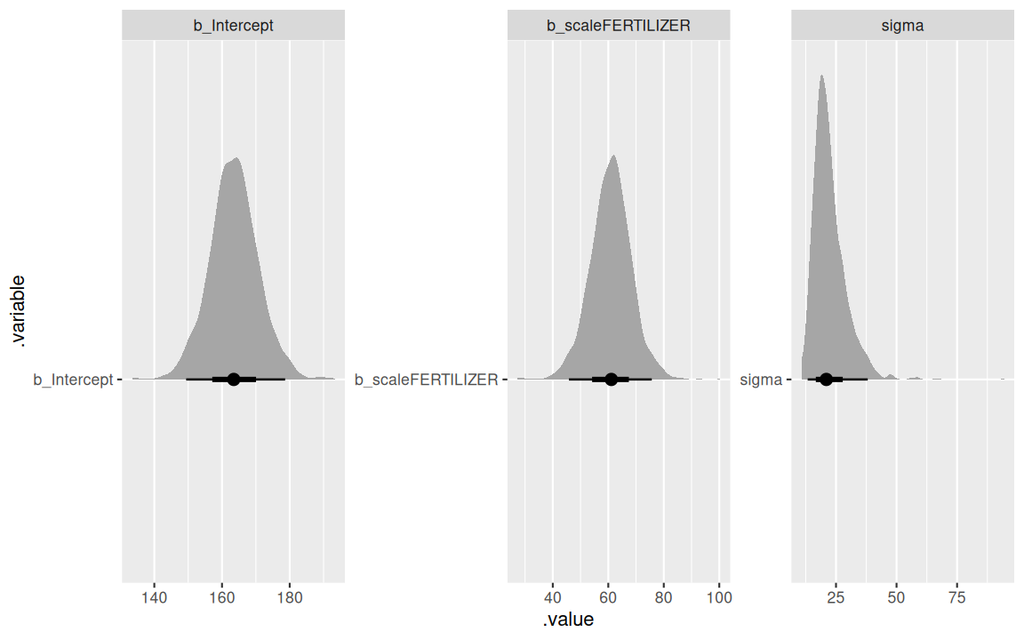

```r
fert_brm3 |>
  gather_draws(b_Intercept, b_scaleFERTILIZER, sigma) |>
  ggplot() +
  stat_halfeye(aes(x = .value, y = .variable)) +
  facet_wrap(~.variable, scales = "free")
```

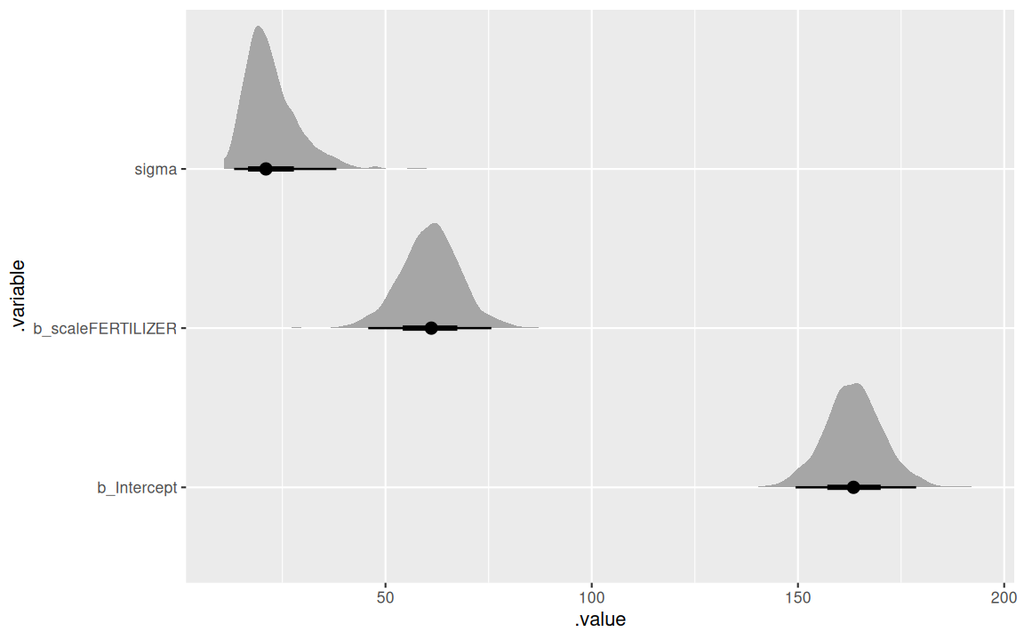

```r
fert_brm3 |>
  gather_draws(b_Intercept, b_scaleFERTILIZER, sigma) |>
  ggplot() +
  stat_halfeye(aes(x = .value, y = .variable))
```

**Conclusions:**

- the estimated intercept (expected yield when fertilizer concentration is 0) is 163.47. This is the median of the posterior distribution for this parameter. Since we scaled the predictor, the intercept represents the expected mean of the response for the average fertilizer concentration.
- the estimated slope (rate at which yield changes per 1 unit change in scaled fertilizer concentration), is 61.11 (mean) or (median). The 95% credibility intervals indicate that we are 95% confident that the slope is between 45.61 and 75.49 - e.g. there is a significant positive trend. So this is the expected change in yeild for a moderate (1 standard deviation) change in fertiliser concentration.
- sigma is estimated to be 21.01

**spread_draws**

Select just the parameters of interest.

```r
fert_brm3 |> spread_draws(b_Intercept, b_scaleFERTILIZER, sigma)
```

```
# A tibble: 2,400 × 6
   .chain .iteration .draw b_Intercept b_scaleFERTILIZER sigma
    <int>      <int> <int>       <dbl>             <dbl> <dbl>
 1      1          1     1        159.              64.2  18.0
 2      1          2     2        145.              72.8  23.4
 3      1          3     3        161.              59.0  22.7
 4      1          4     4        170.              72.8  22.8
 5      1          5     5        162.              63.3  13.2
 6      1          6     6        151.              53.2  20.6
 7      1          7     7        164.              64.8  12.2
 8      1          8     8        158.              55.3  24.9
 9      1          9     9        176.              59.2  26.8
10      1         10    10        165.              58.1  12.8
# ℹ 2,390 more rows
```

```r
# OR via regex
fert_brm3 |> spread_draws(`b_.*|sigma`, regex = TRUE)
```

```
# A tibble: 2,400 × 6
   .chain .iteration .draw b_Intercept b_scaleFERTILIZER sigma
    <int>      <int> <int>       <dbl>             <dbl> <dbl>
 1      1          1     1        159.              64.2  18.0
 2      1          2     2        145.              72.8  23.4
 3      1          3     3        161.              59.0  22.7
 4      1          4     4        170.              72.8  22.8
 5      1          5     5        162.              63.3  13.2
 6      1          6     6        151.              53.2  20.6
 7      1          7     7        164.              64.8  12.2
 8      1          8     8        158.              55.3  24.9
 9      1          9     9        176.              59.2  26.8
10      1         10    10        165.              58.1  12.8
# ℹ 2,390 more rows
```

**bayesplot**

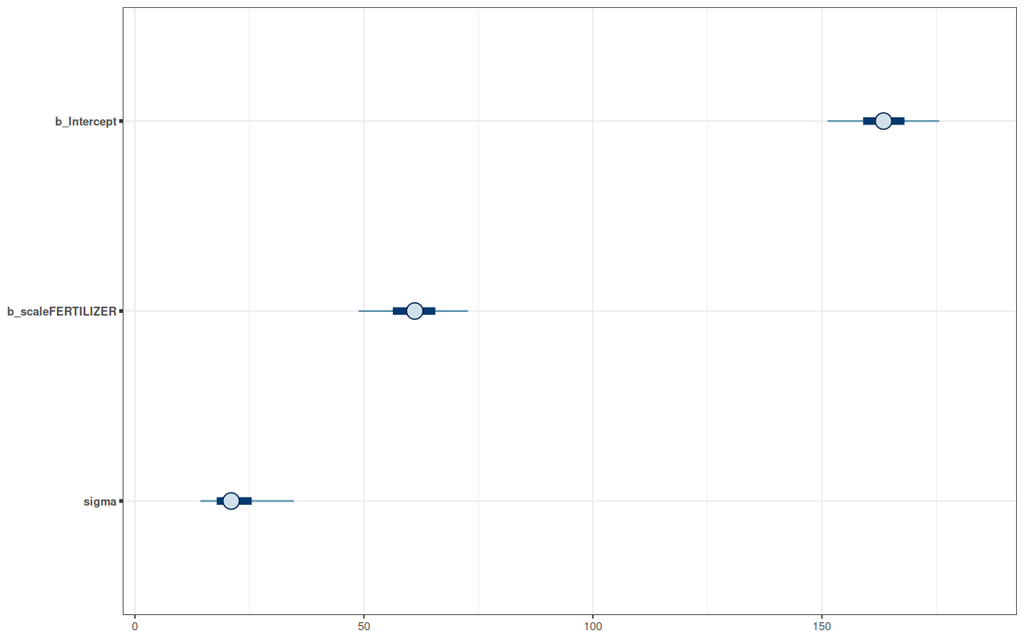

```r
fert_brm3 |> mcmc_plot(type = "intervals")
```

**posterior_samples**

Note, this is now deprecated

```r
fert_brm3 |>
  posterior_samples() |>
  as_tibble()
```

```
# A tibble: 2,400 × 9
   b_Intercept b_scaleFERTILIZER sigma Intercept prior_Intercept prior_b
         <dbl>             <dbl> <dbl>     <dbl>           <dbl>   <dbl>
 1        159.              64.2  18.0      159.           221.    -18.2
 2        145.              72.8  23.4      145.           300.    215.
 3        161.              59.0  22.7      161.           216.    107.
 4        170.              72.8  22.8      170.           212.   -147.
 5        162.              63.3  13.2      162.           190.   -161.
 6        151.              53.2  20.6      151.            66.1    27.8
 7        164.              64.8  12.2      164.           182.    -50.6
 8        158.              55.3  24.9      158.           164.     77.1
 9        176.              59.2  26.8      176.           247.    142.
10        165.              58.1  12.8      165.           211.     90.0
# ℹ 2,390 more rows
# ℹ 3 more variables: prior_sigma <dbl>, lprior <dbl>, lp__ <dbl>
```

**\(R^2\)**

```r
fert_brm3 |>
  bayes_R2(summary = FALSE) |>
  median_hdci()
```

```
          y      ymin      ymax .width .point .interval
1 0.9190366 0.8318385 0.9273001   0.95 median      hdci
```

**Empirical p-value**

It is possible to obtain an empirical p-value (for those that cannot live without p-values). This is essentially compares (for any posterior) that the mean is zero compared to a multivariate distribution with elliptical contours.

```r
mcmcpvalue <- function(samp) {
  ## elementary version that creates an empirical p-value for the
  ## hypothesis that the columns of samp have mean zero versus a
  ## general multivariate distribution with elliptical contours.

  ## differences from the mean standardized by the observed
  ## variance-covariance factor

  ## Note, I put in the bit for single terms
  if (length(dim(samp)) == 0) {
    std <- backsolve(chol(var(samp)), cbind(0, t(samp)) - mean(samp), transpose = TRUE)
    sqdist <- colSums(std * std)
    sum(sqdist[-1] > sqdist[1]) / length(samp)
  } else {
    std <- backsolve(chol(var(samp)), cbind(0, t(samp)) - colMeans(samp), transpose = TRUE)
    sqdist <- colSums(std * std)
    sum(sqdist[-1] > sqdist[1]) / nrow(samp)
  }
}

mcmcpvalue(as.matrix(fert_brm3)[, c("b_scaleFERTILIZER")])
```

```
[1] 0
```

**Modelsummary**

```r
fert_brm3 |> modelsummary(
  statistic = c("conf.low", "conf.high"),
  shape = term ~ statistic
)
```

|  | (1) Est. | (1) 2.5 % | (1) 97.5 % |
| --- | --- | --- | --- |
| b_Intercept | 163.466 | 149.412 | 178.649 |
| b_scaleFERTILIZER | 61.106 | 45.813 | 75.666 |
| sigma | 21.008 | 13.300 | 38.089 |
| Num.Obs. | 10 |  |  |
| R2 | 0.919 |  |  |
| R2 Adj. | 0.891 |  |  |
| ELPD | -45.7 |  |  |
| ELPD s.e. | 1.4 |  |  |
| LOOIC | 91.3 |  |  |
| LOOIC s.e. | 2.9 |  |  |
| WAIC | 91.1 |  |  |
| RMSE | 16.91 |  |  |

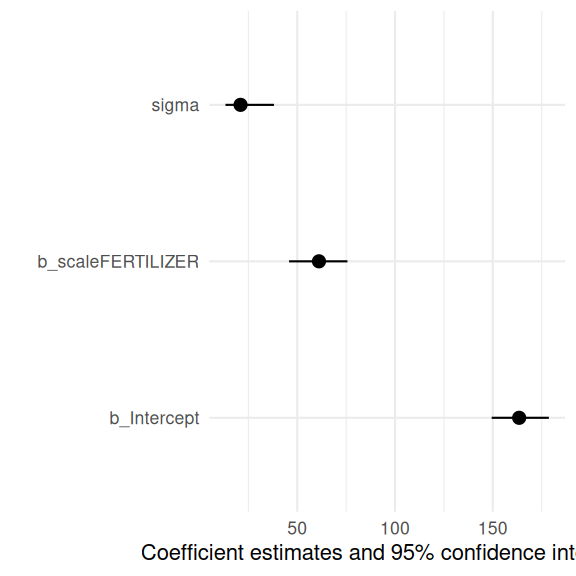

```r
fert_brm3 |> modelplot()
```

**INLA**

INLA captures a summary of the parameter posteriors within the fitted object.

**summary**

```r
fert.inla1 |> summary()
```

```
Time used:
    Pre = 0.232, Running = 0.272, Post = 0.0286, Total = 0.532
Fixed effects:
              mean     sd 0.025quant 0.5quant 0.975quant   mode kld
(Intercept) 52.017 13.486     25.049   52.007     79.046 52.009   0
FERTILIZER   0.811  0.087      0.637    0.811      0.985  0.811   0

Model hyperparameters:
                                         mean    sd 0.025quant 0.5quant
Precision for the Gaussian observations 0.003 0.001      0.001    0.003
                                        0.975quant  mode
Precision for the Gaussian observations      0.007 0.002

Deviance Information Criterion (DIC) ...............: 91.27
Deviance Information Criterion (DIC, saturated) ....: 13.40
Effective number of parameters .....................: 3.09

Watanabe-Akaike information criterion (WAIC) ...: 91.15
Effective number of parameters .................: 2.51

Marginal log-Likelihood:  -55.92
CPO, PIT is computed
Posterior summaries for the linear predictor and the fitted values are computed
(Posterior marginals needs also 'control.compute=list(return.marginals.predictor=TRUE)')
```

**Conclusions:**

- in the initial block of information, we are reminded of the function *call*
- a breakdown of the various components of the time taken for the analysis to run
- the ‘Fixed effects’ indicate that the:
  - estimated Intercept is 52.017 (mean) or 52.007 (median)
  - estimated slope is 0.811 (mean) or 0.811 (median)
  - the 95% Credibility intervals indicate that we are 95% confident that the slope is between 0.637 and 0.985
- the `Model hyperparameters’ indicate that the:
  - the precision of the Gaussian distribution is 0.003 (mean) and 0.003 (median) . Precision is $\tau = 1/\sigma^2$ and thus, $\sigma$ is estimated to be 18.2574186
  - WAIC (Watanabe-Akaike information criterion is estimated to be 91.148

**Plot of posteriors**

**Fixed effects**